# TCGA_LUAD

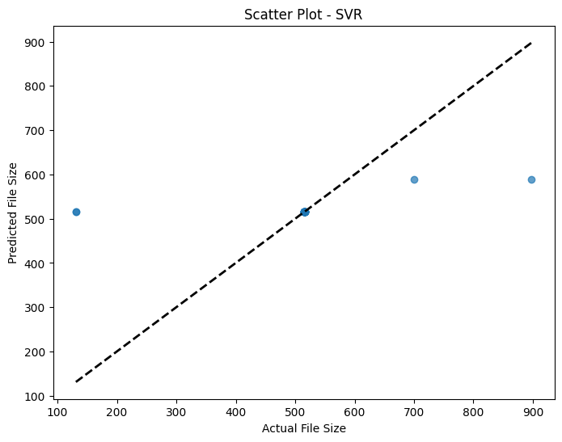

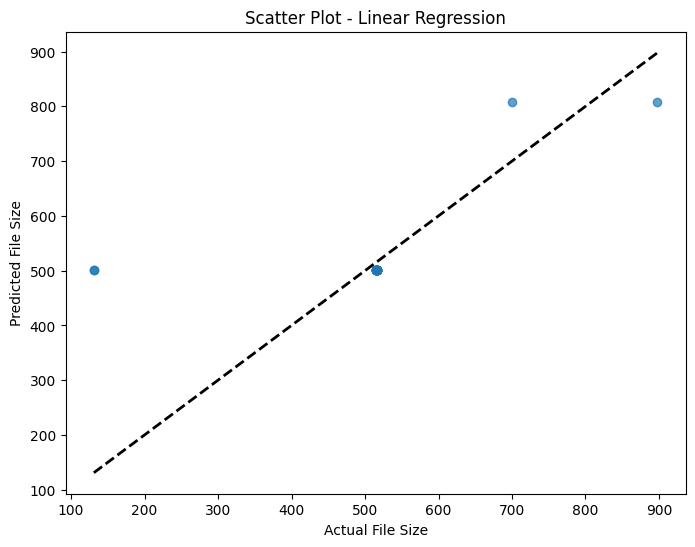

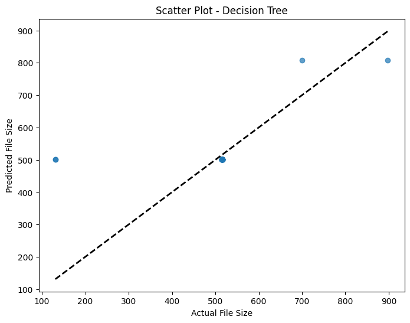

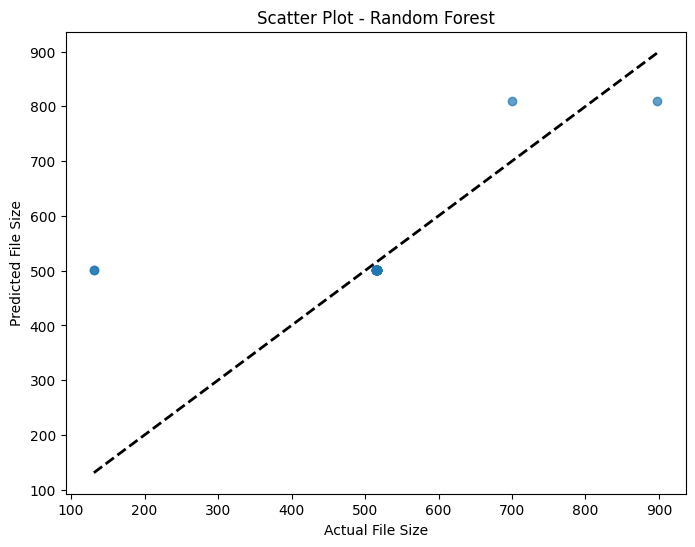

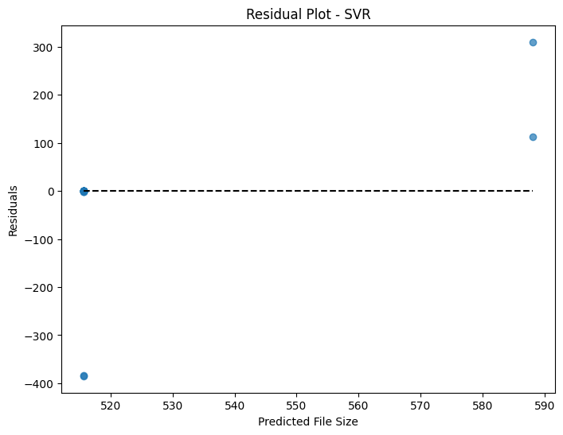

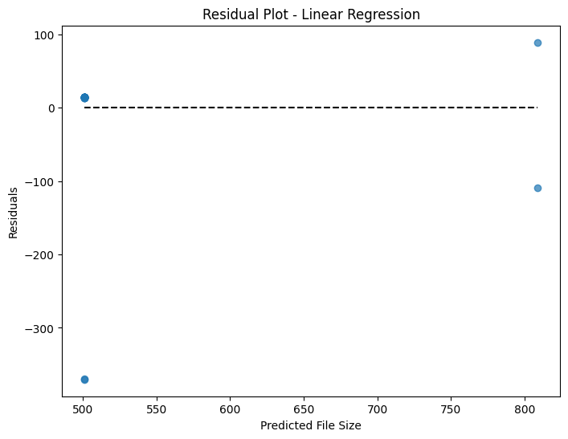

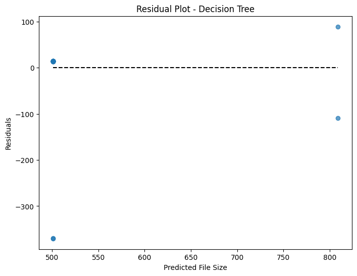

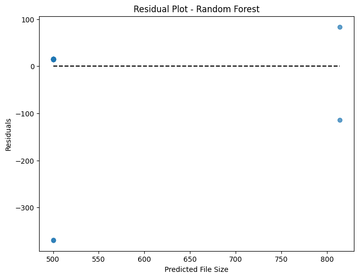

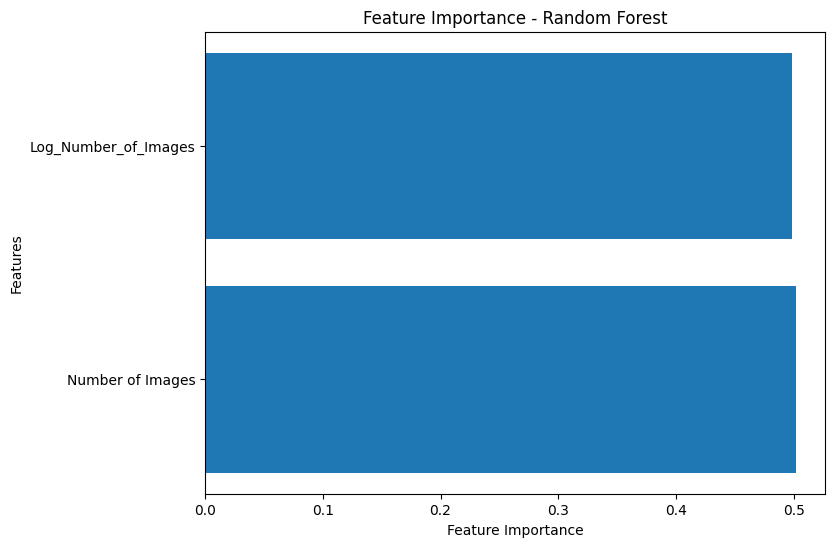

```python
import matplotlib.pyplot as plt
import seaborn as sns

# ... (Previous code for training and evaluating models) ...

# Scatter plots for actual vs. predicted values
for model_name, model in models.items():
    model.fit(X_train, y_train)  # Re-fit the model for visualization
    y_pred = model.predict(X_test)

    plt.figure(figsize=(8, 6))
    plt.scatter(y_test, y_pred, alpha=0.7)
    plt.plot([y_test.min(), y_test.max()], [y_test.min(), y_test.max()], 'k--', lw=2)  # Diagonal line
    plt.xlabel("Actual File Size")
    plt.ylabel("Predicted File Size")
    plt.title(f"Scatter Plot - {model_name}")
    plt.show()

# Residual plots
for model_name, model in models.items():
    model.fit(X_train, y_train)  # Re-fit the model for visualization
    y_pred = model.predict(X_test)
    residuals = y_test - y_pred

    plt.figure(figsize=(8, 6))
    plt.scatter(y_pred, residuals, alpha=0.7)
    plt.hlines(y=0, xmin=y_pred.min(), xmax=y_pred.max(), linestyles='--', colors='k')  # Horizontal line at 0
    plt.xlabel("Predicted File Size")
    plt.ylabel("Residuals")
    plt.title(f"Residual Plot - {model_name}")
    plt.show()

# Feature importance plot (for tree-based models)
if 'Random Forest' in models:
    rf_model = models['Random Forest']
    rf_model.fit(X_train, y_train)  # Re-fit the model for visualization
    importances = rf_model.feature_importances_
    feature_names = X_train.columns

    plt.figure(figsize=(8, 6))
    plt.barh(feature_names, importances)
    plt.xlabel("Feature Importance")
    plt.ylabel("Features")
    plt.title("Feature Importance - Random Forest")
    plt.show()
```

Explanation:

Scatter plots: We create scatter plots to visualize the relationship between actual and predicted 'File Size' for each model. The diagonal line represents a perfect prediction. Points closer to the diagonal line indicate better model performance.

Residual plots: We create residual plots to analyze the distribution of errors (residuals) for each model. Ideally, residuals should be randomly scattered around the horizontal line at 0, indicating no systematic patterns in the errors.

Feature importance plot (for tree-based models): We create a feature importance plot for the Random Forest model (if it's in your models dictionary). This plot shows the relative importance of each feature in making predictions.

By examining these visualizations, you can gain insights into the models' behavior, identify potential areas for improvement (e.g., non-linear relationships, heteroscedasticity in residuals), and understand the influence of different features on predictions. This information can guide further model refinement and feature engineering efforts. Remember to adjust the code if you have different model names or want to include other types of visualizations.

**Deployment** or **Save the Model**

```python
import joblib

# Save the model
joblib.dump(best_model, 'trained_model.pkl')

# Load the model
loaded_model = joblib.load('trained_model.pkl')
```

**Random Forest**

```
Mean Squared Error: 12426.679394318651
Root Mean Squared Error: 111.47501690656365
R-squared: 0.37083232196314786

Confusion Matrix:
 [[22  0]
 [ 0  2]]
F1-score: 1.0
Precision: 1.0
```

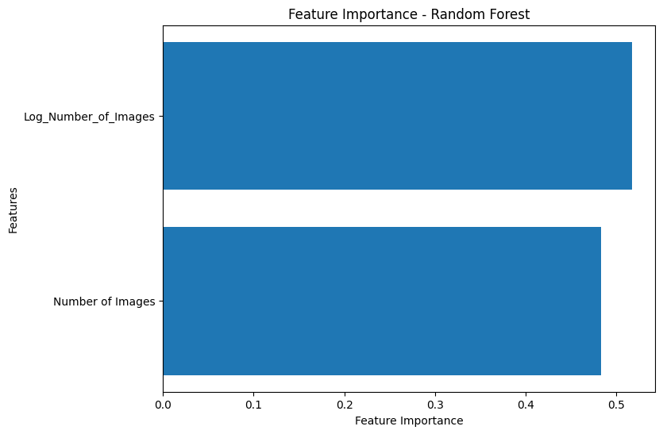

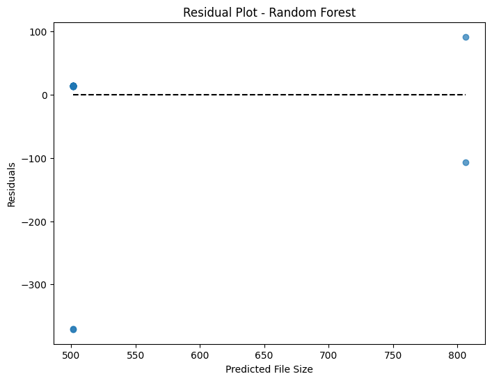

```
Best Parameters: {'max_depth': None, 'n_estimators': 100}
```

```python
from sklearn.ensemble import RandomForestRegressor
from sklearn.metrics import mean_squared_error, r2_score, f1_score, confusion_matrix, precision_score


# ... (Previous code for loading and preparing data, including feature engineering) ...

# 1. Train the Random Forest model
rf_model = RandomForestRegressor(random_state=42)  # You can adjust hyperparameters here
rf_model.fit(X_train, y_train)

# 2. Make predictions
y_pred = rf_model.predict(X_test)

# 3. Evaluate the model (regression metrics)
mse = mean_squared_error(y_test, y_pred)
rmse = np.sqrt(mse)
r2 = r2_score(y_test, y_pred)
print(f"Mean Squared Error: {mse}")
print(f"Root Mean Squared Error: {rmse}")
print(f"R-squared: {r2}")

# 4. Adapt classification metrics (using threshold from Step 2)
threshold = y_train.mean()
y_pred_binary = [1 if pred > threshold else 0 for pred in y_pred]
y_test_binary = [1 if val > threshold else 0 for val in y_test]
cm = confusion_matrix(y_test_binary, y_pred_binary)
f1 = f1_score(y_test_binary, y_pred_binary)
precision = precision_score(y_test_binary, y_pred_binary)
print("\nConfusion Matrix:\n", cm)
print(f"F1-score: {f1}")
print(f"Precision: {precision}")

# 5. Visualize confusion matrix
plt.figure(figsize=(6, 4))
sns.heatmap(cm, annot=True, fmt="d", cmap="Blues", cbar=False)
plt.xlabel("Predicted")
plt.ylabel("Actual")
plt.title("Confusion Matrix (Random Forest)")
plt.show()

# 6. Feature Importance Analysis
importances = rf_model.feature_importances_
feature_names = X_train.columns
plt.figure(figsize=(8, 6))
plt.barh(feature_names, importances)
plt.xlabel("Feature Importance")
plt.ylabel("Features")
plt.title("Feature Importance - Random Forest")
plt.show()

# 7. Residual Analysis
residuals = y_test - y_pred
plt.figure(figsize=(8, 6))
plt.scatter(y_pred, residuals, alpha=0.7)
plt.hlines(y=0, xmin=y_pred.min(), xmax=y_pred.max(), linestyles='--', colors='k')
plt.xlabel("Predicted File Size")
plt.ylabel("Residuals")
plt.title("Residual Plot - Random Forest")
plt.show()

# 8. Hyperparameter Tuning (Revisited - example using GridSearchCV)
from sklearn.model_selection import GridSearchCV
param_grid = {
    'n_estimators': [100, 200, 300],
    'max_depth': [None, 10, 20],
    # Add other hyperparameters to explore
}
grid_search = GridSearchCV(RandomForestRegressor(random_state=42), param_grid, scoring='neg_mean_squared_error', cv=5)
grid_search.fit(X_train, y_train)
best_rf_model = grid_search.best_estimator_
print("Best Parameters:", grid_search.best_params_)

# 9. Re-evaluate the best model and visualize results (similar to steps 2-7)
# ...
```

[output not shown]

```python
# Confusion Matrix
print("\nConfusion Matrix:\n", cm)  # 'cm' is the confusion matrix variable

# F1-score
print(f"F1-score: {f1}")  # 'f1' is the F1-score variable

# Precision
print(f"Precision: {precision}")  # 'precision' is the precision variable
# Visualize confusion matrix
plt.figure(figsize=(6, 4))
sns.heatmap(cm, annot=True, fmt="d", cmap="Blues", cbar=False)
plt.xlabel("Predicted")
plt.ylabel("Actual")
plt.title("Confusion Matrix (Random Forest)")
plt.show()
```

[output not shown]

```
Confusion Matrix:
 [[22  0]
 [ 0  2]]
F1-score: 1.0
Precision: 1.0
```

Explanation:

Train the Random Forest model: We create and train a RandomForestRegressor with an initial set of hyperparameters. Make predictions and evaluate: We make predictions on the test set and evaluate the model using regression and adapted classification metrics. Visualize confusion matrix: We create a heatmap of the confusion matrix. Feature Importance Analysis: We visualize the feature importances using a bar chart. Residual Analysis: We create a residual plot to analyze the distribution of errors. Hyperparameter Tuning: We use GridSearchCV to find the best hyperparameter settings. You can add more hyperparameters to explore in the param_grid. Re-evaluate and visualize: After hyperparameter tuning, re-evaluate the best model using the same metrics and visualizations as before. This refined approach focuses specifically on the Random Forest model and incorporates the analysis and refinement techniques we discussed earlier. Remember to adjust the hyperparameters and feature engineering steps based on your data and desired outcomes.

```
Mean Squared Error: 12411.497153416252
Root Mean Squared Error: 111.40689903868724
R-squared: 0.37160100480695946

Confusion Matrix:
 [[22  0]
 [ 0  2]]
F1-score: 1.0
Precision: 1.0
```

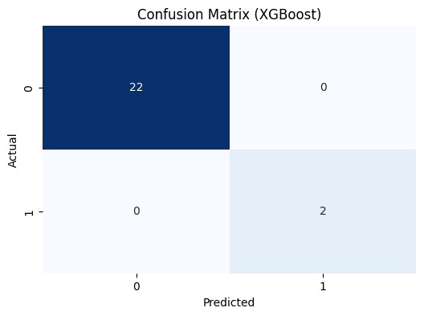

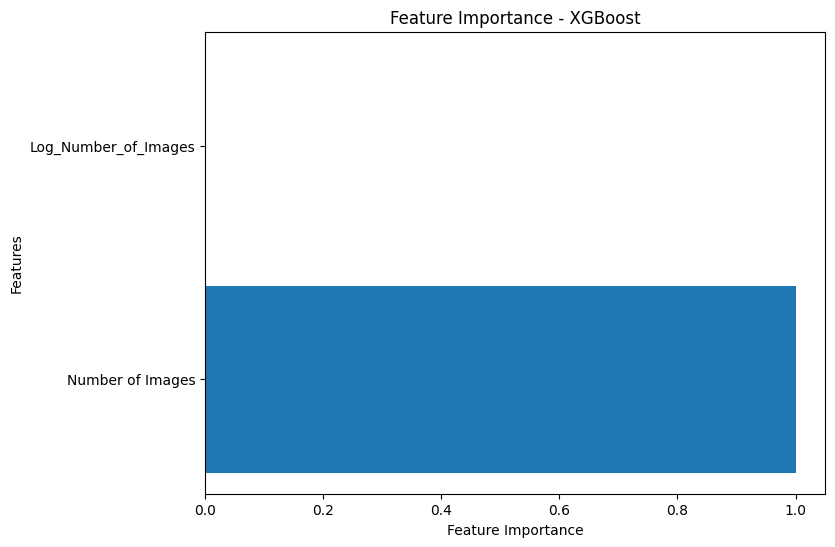

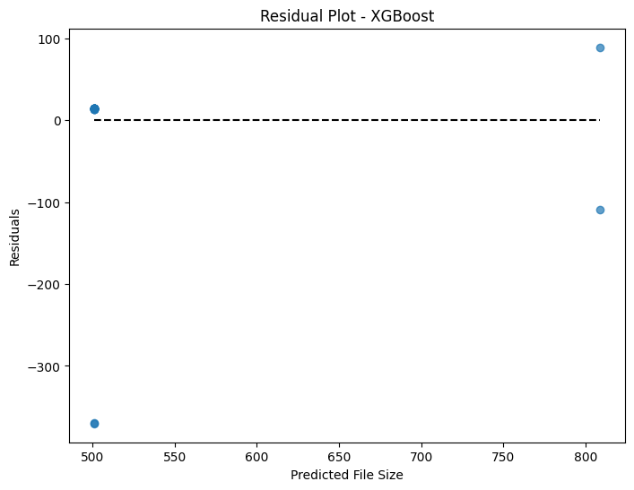

```python
import xgboost as xgb
from sklearn.metrics import mean_squared_error, r2_score, f1_score, confusion_matrix, precision_score


# ... (Previous code for loading and preparing data, including feature engineering) ...

# 1. Train the XGBoost model
xgb_model = xgb.XGBRegressor(random_state=42)  # You can adjust hyperparameters here
xgb_model.fit(X_train, y_train)

# 2. Make predictions
y_pred = xgb_model.predict(X_test)

# 3. Evaluate the model (regression metrics)
mse = mean_squared_error(y_test, y_pred)
rmse = np.sqrt(mse)
r2 = r2_score(y_test, y_pred)
print(f"Mean Squared Error: {mse}")
print(f"Root Mean Squared Error: {rmse}")
print(f"R-squared: {r2}")

# 4. Adapt classification metrics (using threshold from Step 2)
threshold = y_train.mean()
y_pred_binary = [1 if pred > threshold else 0 for pred in y_pred]
y_test_binary = [1 if val > threshold else 0 for val in y_test]
cm = confusion_matrix(y_test_binary, y_pred_binary)
f1 = f1_score(y_test_binary, y_pred_binary)
precision = precision_score(y_test_binary, y_pred_binary)
print("\nConfusion Matrix:\n", cm)
print(f"F1-score: {f1}")
print(f"Precision: {precision}")

# 5. Visualize confusion matrix
plt.figure(figsize=(6, 4))
sns.heatmap(cm, annot=True, fmt="d", cmap="Blues", cbar=False)
plt.xlabel("Predicted")
plt.ylabel("Actual")
plt.title("Confusion Matrix (XGBoost)")
plt.show()

# 6. Feature Importance Analysis (for XGBoost)
importances = xgb_model.feature_importances_
feature_names = X_train.columns
plt.figure(figsize=(8, 6))
plt.barh(feature_names, importances)
plt.xlabel("Feature Importance")
plt.ylabel("Features")
plt.title("Feature Importance - XGBoost")
plt.show()

# 7. Residual Analysis
residuals = y_test - y_pred
plt.figure(figsize=(8, 6))
plt.scatter(y_pred, residuals, alpha=0.7)
plt.hlines(y=0, xmin=y_pred.min(), xmax=y_pred.max(), linestyles='--', colors='k')
plt.xlabel("Predicted File Size")
plt.ylabel("Residuals")
plt.title("Residual Plot - XGBoost")
plt.show()
```

```python
threshold = y_train.mean() * 0.9  # Example: Adjust threshold to 90% of the mean
   # ... (Rest of your XGBoost code) ...
```

```
Confusion Matrix:
 [[22  0]
 [ 0  2]]
F1-score: 1.0
```

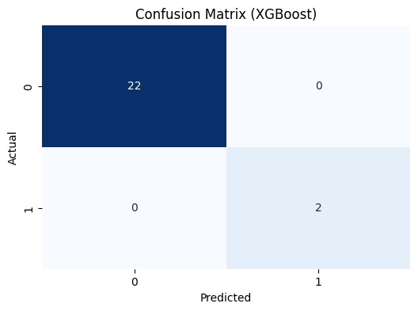

```python
# ... (Your XGBoost model code) ...

# Confusion Matrix
print("\nConfusion Matrix:\n", cm)  # 'cm' is the confusion matrix variable

# F1-score
print(f"F1-score: {f1}")  # 'f1' is the F1-score variable

# Visualize confusion matrix
plt.figure(figsize=(6, 4))
sns.heatmap(cm, annot=True, fmt="d", cmap="Blues", cbar=False)
plt.xlabel("Predicted")
plt.ylabel("Actual")
plt.title("Confusion Matrix (XGBoost)")
plt.show()
```

```python
import pandas as pd
import numpy as np
from sklearn.model_selection import train_test_split
import xgboost as xgb
from sklearn.metrics import mean_squared_error, r2_score, f1_score, confusion_matrix, precision_score
import matplotlib.pyplot as plt
import seaborn as sns

# ... (Previous code for loading and preparing data) ...

# Feature Engineering: Create a new feature (example - logarithmic transformation)
numerical_data['Log_Number_of_Images'] = np.log1p(numerical_data['Number of Images'])

# Prepare data with the new feature
X = numerical_data[['Number of Images', 'Log_Number_of_Images']]  # Include both original and new features
y = numerical_data['File Size']

# Split data into training and testing sets
X_train, X_test, y_train, y_test = train_test_split(X, y, test_size=0.2, random_state=42)

# 1. Train the XGBoost model
xgb_model = xgb.XGBRegressor(random_state=42)  # You can adjust hyperparameters here
xgb_model.fit(X_train, y_train)

# 2. Make predictions
y_pred = xgb_model.predict(X_test)

# ... (Rest of the code for evaluation, visualization, etc. - same as before) ...
```

Hyperparameter Tuning (Revisited with a Focus on XGBoost)

```python
import xgboost as xgb
from sklearn.model_selection import GridSearchCV

# Define the parameter grid to search
param_grid = {
    'learning_rate': [0.01, 0.1, 0.2],
    'max_depth': [3, 5, 7],
    'subsample': [0.8, 0.9, 1.0],
    'colsample_bytree': [0.8, 0.9, 1.0],
    'reg_alpha': [0, 0.1, 0.5],
    'reg_lambda': [0, 0.1, 0.5],
}

# Create a GridSearchCV object
grid_search = GridSearchCV(
    estimator=xgb.XGBRegressor(random_state=42),
    param_grid=param_grid,
    scoring='neg_mean_squared_error',  # Or other relevant scoring metric
    cv=5,  # Number of cross-validation folds
    n_jobs=-1,  # Use all available CPU cores
)

# Fit the grid search to the training data
grid_search.fit(X_train, y_train)

# Get the best model and its parameters
best_xgb_model = grid_search.best_estimator_
best_params = grid_search.best_params_

print("Best Parameters:", best_params)

# Evaluate the best model on the test set
# ... (Rest of the evaluation code) ...
```

```
Best Parameters: {'colsample_bytree': 0.8, 'learning_rate': 0.1, 'max_depth': 3, 'reg_alpha': 0.1, 'reg_lambda': 0.5, 'subsample': 0.9}
```

Explore Advanced Feature Engineering Techniques (Example: Polynomial Features)

```python
from sklearn.preprocessing import PolynomialFeatures

# Create polynomial features
poly = PolynomialFeatures(degree=2)  # Adjust degree as needed
X_train_poly = poly.fit_transform(X_train)
X_test_poly = poly.transform(X_test)

# Train XGBoost with polynomial features
xgb_model = xgb.XGBRegressor(random_state=42)
xgb_model.fit(X_train_poly, y_train)

# Make predictions and evaluate
# ... (Rest of the evaluation code) ...
```

```
XGBRegressor(base_score=None, booster=None, callbacks=None,
             colsample_bylevel=None, colsample_bynode=None,
             colsample_bytree=None, device=None, early_stopping_rounds=None,
             enable_categorical=False, eval_metric=None, feature_types=None,
             gamma=None, grow_policy=None, importance_type=None,
             interaction_constraints=None, learning_rate=None, max_bin=None,
             max_cat_threshold=None, max_cat_to_onehot=None,
             max_delta_step=None, max_depth=None, max_leaves=None,
             min_child_weight=None, missing=nan, monotone_constraints=None,
             multi_strategy=None, n_estimators=None, n_jobs=None,
             num_parallel_tree=None, random_state=42, ...)
```

Ensemble Methods (Example: Stacking)

```python
from sklearn.ensemble import StackingRegressor

# Define base models (e.g., multiple XGBoost models with different hyperparameters)
base_models = [
    ('xgb1', xgb.XGBRegressor(random_state=42, learning_rate=0.1)),
    ('xgb2', xgb.XGBRegressor(random_state=42, learning_rate=0.01, max_depth=5)),
    # Add more base models as needed
]

# Define the stacking regressor
stacking_model = StackingRegressor(
    estimators=base_models,
    final_estimator=xgb.XGBRegressor(random_state=42),  # Or other final estimator
)

# Train the stacking model
stacking_model.fit(X_train, y_train)

# Make predictions and evaluate
# ... (Rest of the evaluation code) ...
```

[output not shown]